# Determining Risk Factors for Injuries and Fatalities in Road Collisions

## Introduction

The Canadian National Collision Database contains information on all police-reported motor vehicle collisions over many years. The attached dataset “2019_dataset_en.csv” contains such information for 272301 collisions in the year 2019.

This R Notebook will load this dataset, clean, inspect and visualize its contents, and produce a machine learning model to predict the severity of a collision (whether it resulted in no injuries, non-fatal, or fatal injuries) given a subset of the other available information.

## Loading libraries

The following libraries will be required to run this R Notebook:

```r
library(readr)
library(dplyr)
library(plyr)
library(tidyverse)
library(RColorBrewer)
library(GGally)
library(data.table)
library(sf)
library(ggspatial)
library(tmap)
library(grid)
library(gridExtra)
library(patchwork)
```

## Loading the dataset

The dataset will be loaded as a CSV into the active R environment, it must be located in the same directory as this R Notebook:

```r
data <- read_csv("2019_dataset_en.csv", show_col_types = FALSE)
```

## Cleaning the data

To clean the data, six columns containing unique identifiers, the year (2019), and other variables not relevant or inhibitory to this machine learning task must be removed as follows:

```r
data <- data %>%
  select(-c(C_YEAR, C_SEV, V_ID, P_ID, P_SAFE, C_CASE))
```

For the meanings of these column names, refer to the attached “data_dictionary.pdf” for details.

The remaining columns are almost exclusively categorical variables, and contain categories for unknown and missing data. These must be removed for the machine learning model to process the dataset.

```r
data <- data %>%
  filter(C_MNTH!="UU",C_MNTH!="XX") %>%
  filter(C_WDAY!="U") %>%
  filter(C_HOUR!="UU") %>%
  filter(C_VEHS!="UU",C_VEHS!="XX") %>%
  filter(C_CONF!="QQ",C_CONF!="UU",C_CONF!="XX") %>%
  filter(C_RCFG!="QQ",C_RCFG!="UU",C_RCFG!="XX") %>%
  filter(C_WTHR!="U",C_WTHR!="X",C_WTHR!="Q") %>%
  filter(C_RSUR!="U",C_RSUR!="X",C_RSUR!="Q") %>%
  filter(C_RALN!="U",C_RALN!="X",C_RALN!="Q") %>%
  filter(C_TRAF!="QQ",C_TRAF!="UU",C_TRAF!="XX") %>%
  filter(V_TYPE!="NN",V_TYPE!="QQ",V_TYPE!="UU",V_TYPE!="XX") %>%
  filter(V_YEAR!="NNNN",V_YEAR!="UUUU",V_YEAR!="XXXX") %>%
  filter(P_SEX!="N",P_SEX!="U",P_SEX!="X") %>%
  filter(P_AGE!="NN",P_AGE!="UU",P_AGE!="XX") %>%
  filter(P_PSN!="NN",P_PSN!="QQ",P_PSN!="UU",P_PSN!="XX") %>%
  filter(P_USER!="U") %>%
  filter(P_ISEV!="N",P_ISEV!="U")
```

Removing these leaves 17 of the original 23 columns and 167803 of the original 272301 observations. Finally, the most of remaining data must be converted to factors / categorical variables, and some variables will be grouped into fewer categories than they began with.

```r
# Group the C_CONF column while naming categories.
data <- data %>%
  mutate(C_CONF = (ifelse(data$C_CONF <= 10, 'Single Vehicle',
                    ifelse(data$C_CONF>20 & data$C_CONF <30, '2 Vehicles',
                    ifelse(data$C_CONF>30 & data$C_CONF<40,'2 Vehicles Head On','2 Vehicles Parked')))))

# Convert most variables to factors and some to numeric.
data$C_MNTH <- as.factor(data$C_MNTH)
data$C_WDAY <- as.factor(data$C_WDAY)
data$C_HOUR <- as.numeric(data$C_HOUR)
data$C_VEHS <- as.numeric(data$C_VEHS)
data$C_CONF <- as.factor(data$C_CONF)
data$C_RCFG <- as.factor(data$C_RCFG)
data$C_WTHR <- as.factor(data$C_WTHR)
data$C_RSUR <- as.factor(data$C_RSUR)
data$C_RALN <- as.factor(data$C_RALN)
data$C_TRAF <- as.factor(data$C_TRAF)
data$V_TYPE <- as.factor(data$V_TYPE)
data$V_YEAR <- as.numeric(data$V_YEAR)
data$P_SEX <- as.factor(data$P_SEX)
data$P_AGE <- as.numeric(data$P_AGE)
data$P_PSN <- as.factor(data$P_PSN)
data$P_ISEV <- as.factor(data$P_ISEV)
data$P_USER <- as.factor(data$P_USER)
```

To improve the readability of the data for the remainder of this script, the values of categorical variables and the columns will be assigned English names:

```r
# Assign names to values of categorical variables.
data <- data %>%
  mutate(C_MNTH = recode(C_MNTH,
                        "1" = "Jan", "2" = "Feb", "3" = "Mar", "4" = "Apr",
                        "5" = "May", "6" = "Jun", "7" = "Jul", "8" = "Aug",
                        "9" = "Sep", "10" = "Oct", "11" = "Nov", "12" = "Dec")) %>%
  mutate(C_WDAY = recode(C_WDAY,
                        "1" = "Mon", "2" = "Tue", "3" = "Wed", "4" = "Thu",
                        "5" = "Fri", "6" = "Sat", "7" = "Sun")) %>%
  mutate(C_RCFG = recode(C_RCFG,
                         "1" = "Non-Intersection",
                         "2" = "Intersection - 2 public roadways",
                         "3" = "Intersection - parking, driveway etc.",
                         "4" = "Railroad level crossing",
                         "5" = "Bridge, overpass, viaduct",
                         "6" = "Tunnel or underpass",
                         "7" = "Passing or climbing lane",
                         "8" = "Ramp",
                         "9" = "Traffic circle",
                         "10" = "Express lane of a freeway",
                         "11" = "Collector lane of a freeway",
                         "12" = "Transfer lane of a freeway")) %>%
  mutate(C_WTHR = recode(C_WTHR,
                         "1" = "Clear & sunny", "2" = "Cloudy, no precipitation",
                         "3" = "Raining", "4" = "Snowing",
                         "5" = "Freezing rain, sleet, hail",
                         "6" = "Visibility limitation", "7" = "Strong wind")) %>%
  mutate(C_RSUR = recode(C_RSUR,
                         "1" = "Dry, normal", "2" = "Wet", "3" = "Snow",
                         "4" = "Slush, wet snow", "5" = "Icy", "6" = "Sand/gravel/dirt",
                         "7" = "Muddy", "8" = "Oil", "9" = "Flooded")) %>%
  mutate(C_RALN = recode(C_RALN,
                         "1" = "Straight and level", "2" = "Straight with gradient",
                         "3" = "Curved and level", "4" = "Curved with gradient",
                         "5" = "Top of hill or gradient", "6" = "bottom of hill or gradient")) %>%
  mutate(C_TRAF = recode(C_TRAF,
                         "1" = "Traffic signals fully operational",
                         "2" = "Traffic signals in flashing mode", "3" = "Stop sign",
                         "4" = "Yield sign", "5" = "Warning sign",
                         "6" = "Pedestrian crosswalk", "7" = "Police officer",
                         "8" = "School guard, flagman", "9" = "School crossing",
                         "10" = "Reduced speed zone", "11" = "No passing zone sign",
                         "12" = "Marking on the road",
                         "13" = "School bus - signal lights flashing",
                         "14" = "School bus - signal lights not flashing",
                         "15" = "Railway crossing with signals, gates",
                         "16" = "Railway crossing with signs only",
                         "17" = "Control device not specified",
                         "18" = "No control present")) %>%
  mutate(V_TYPE = recode(V_TYPE,
                         "1" = "Light duty vehicle", "5" = "Panel/cargo van",
                         "6" = "Other trucks and vans", "7" = "Unit trucks > 4536 kg",
                         "8" = "Road tractor", "9" = "School bus",
                         "10" = "Smaller school bus", "11" = "Urban and intercity bus",
                         "14" = "Motorcycle and moped", "16" = "Off road vehicles",
                         "17" = "Bicycle", "18" = "Purpose-built motorhome",
                         "19" = "Farm equipment", "20" = "Construction equipment",
                         "21" = "Fire engine", "22" = "Snowmobile", "23" = "Streetcar")) %>%
  mutate(P_PSN = recode(P_PSN,
                        "11" = "Driver", "12" = "Front row, center",
                        "13" = "Front row, right outboard", "21" = "Second row, left outboard",
                        "22" = "Second row, center", "23" = "Second Row, right outboard",
                        "31" = "Third row, left outboard", "32" = "Third row, center",
                        "33" = "Third row, right outboard", "96" = "Position unknown, but on-board",
                        "97" = "Sitting on someone's lap", "98" = "Outside passenger compartment",
                        "99" = "Pedestrian")) %>%
  mutate(P_ISEV = recode(P_ISEV,
                         "1" = "No injury", "2" = "Injury", "3" = "Fatality")) %>%
  mutate(P_USER = recode(P_USER,
                         "1" = "Motor vehicle driver", "2" = "Motor vehicle passenger",
                         "3" = "Pedestrian", "4" = "Bicyclist", "5" = "Motorcyclist"))
# Assign column names.
names(data) <- c("Month", "Weekday", "Hour", "Vehicles", "CollisionType",
                   "RoadConfig", "Weather", "RoadSurface",
                  "RoadAlignment", "Traffic", "VehicleType",
                  "VehicleYear", "PersonSex", "PersonAge",
                  "PersonPosition", "InjurySeverity", "UserType")
```

With these modifications, the data is mostly prepared for machine learning tasks, and must now be visualized to show any more subtle problems that may appear during training of a model.

## Exploratory Data Analysis & Visualization

First of all, getting a count of each level of injury severity reveals that the amount of collisions resulting in no injury or an injury vastly outweighs the amount of fatalities. This has implications for how we should display the data: when all 3 variables are displayed in the same graph, the fatalities are dwarfed by the no-injury and injury entries to the point where it becomes impossible to examine trends in fatalities. Therefore, we found it useful in most situations to create separate plots for fatalities in order to properly visualize them.

```
## No injury    Injury  Fatality
##     76530     90299       974
```

### Month, weekday, and hour

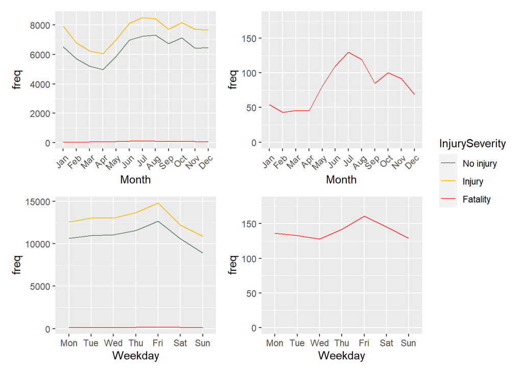

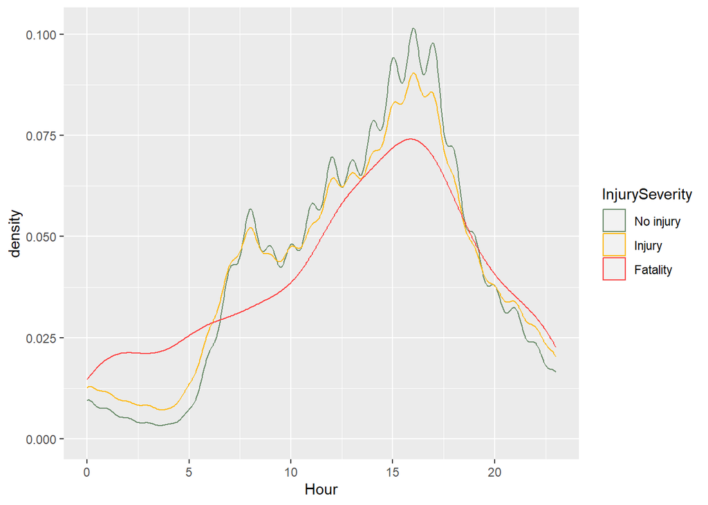

With these graphs, we can see that collisions of all types follow the same general trends over the course of the year & course of each week. The shape of the lines for No Injury and Injury are nearly the same in both graphs. Here are some trends of note:

Fatalities follow the same general pattern, but note that there seems to be a consistent low level of fatalities from Jan-Apr, whereas for other types of collisions the number starts higher and then decreases.

Over the course of a week, overall collisions:

- Increase over the week, peaking on Friday.
- Decrease sharply over the weekend

The decrease over the weekend is likely due to reduced commuting levels. Fatalities follow the same general pattern, but are slightly higher on Mondays & Tuesdays, with the lowest amount of fatalities on Wednesday.

### Demographics

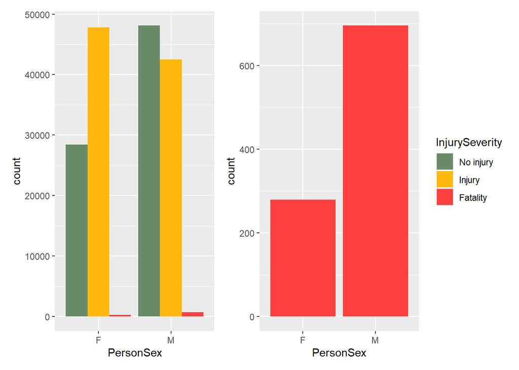

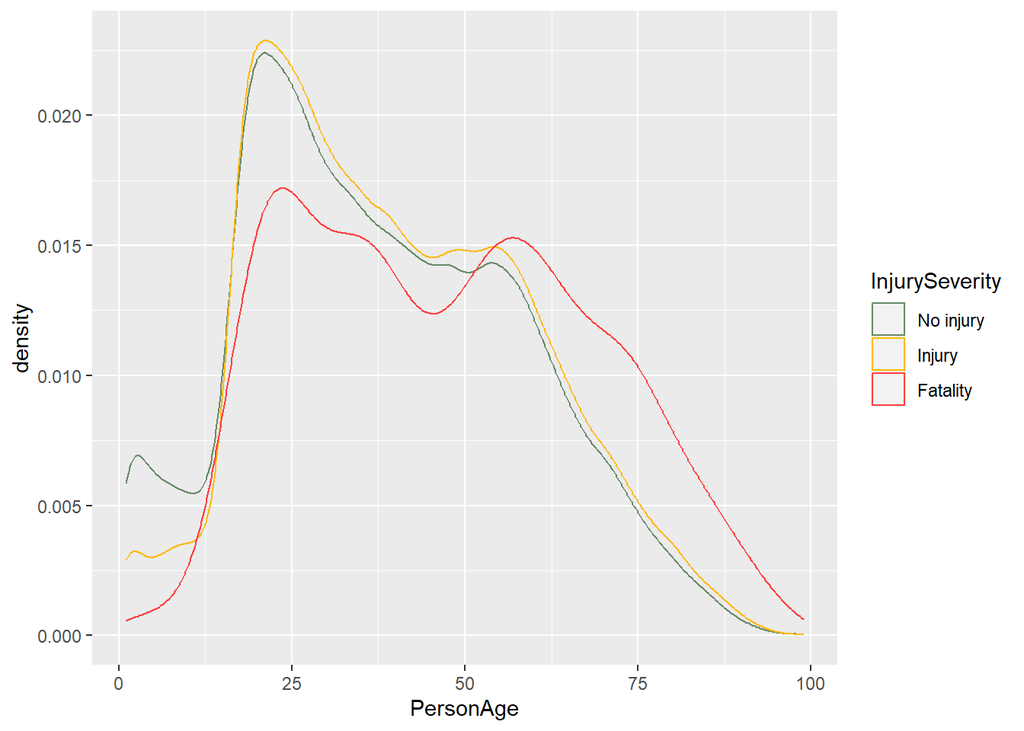

Plotting the data for sex reveals some insights: - There are more than 2 times as many male deaths compared to female deaths - Collisions involving women have a higher proportion of injuries to no injuries - Collisions involving men have a slightly higher rate of no injuries to injuries

In the density plot for injury vs age: - No Injury and Injury rates are nearly identical, except in children under 12, who have a lower rate of injury - Children under the age of 12 also have a lower share of deaths. - Over the age of about 50, there are proportionately more deaths

### Road & Weather Conditions

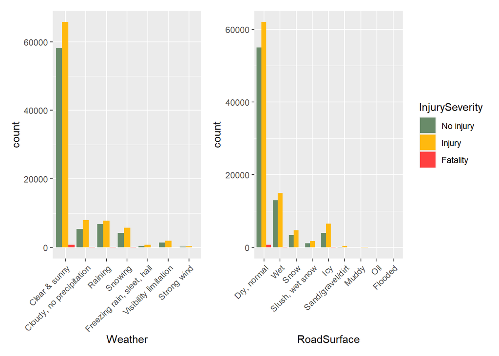

Making an initial set of bar charts for weather & road surface conditions, we can see a problem right away - an overwhelming majority of these entries were recorded with clear/sunny weather and dry/normal road conditions. To some this might imply that vehicle collisions are much more likely to happen under clear & dry conditions, but intuitively we know this isn’t true. Instead it likely means that there was mostly sunny & dry conditions at most times throughout the country. Also, we are not trying to find out under which conditions someone is likely to have a vehicle collision - we are trying to find out which conditions result in a higher chance of injury or fatality if one gets in a vehicle collision.

The charts can be redone to show porportions:

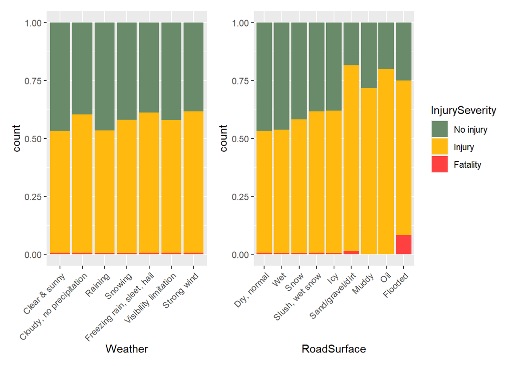

First, we create bar charts to see how many collisions of each severity there are according to each variable. Most of the variables are either categorical, or integer numbers so bar charts are the best option.

Bar charts are displayed grouped by theme:

- Time
- Demographics
- Weather & road conditions
- Vehicle info
- Road info
- Driver/passenger info
- Collision info

Note that for all variables, the amount of fatalities is drastically lower than the amount of injuries and non-injuries, to the point where it’s impossible to view patterns in the data. Therefore, for each varaible there is a separate chart to show how fatalities correlate with each variable.

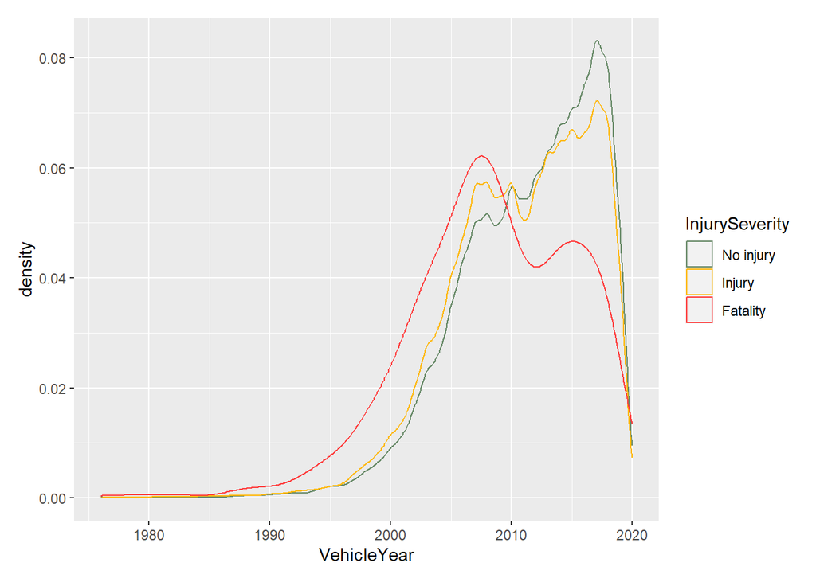

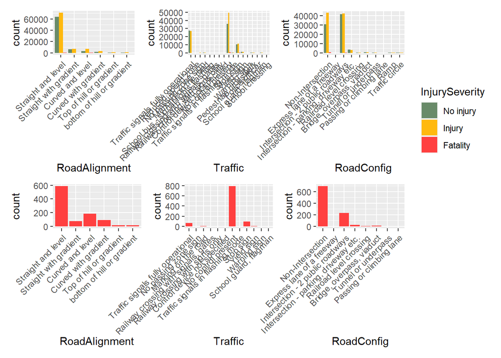

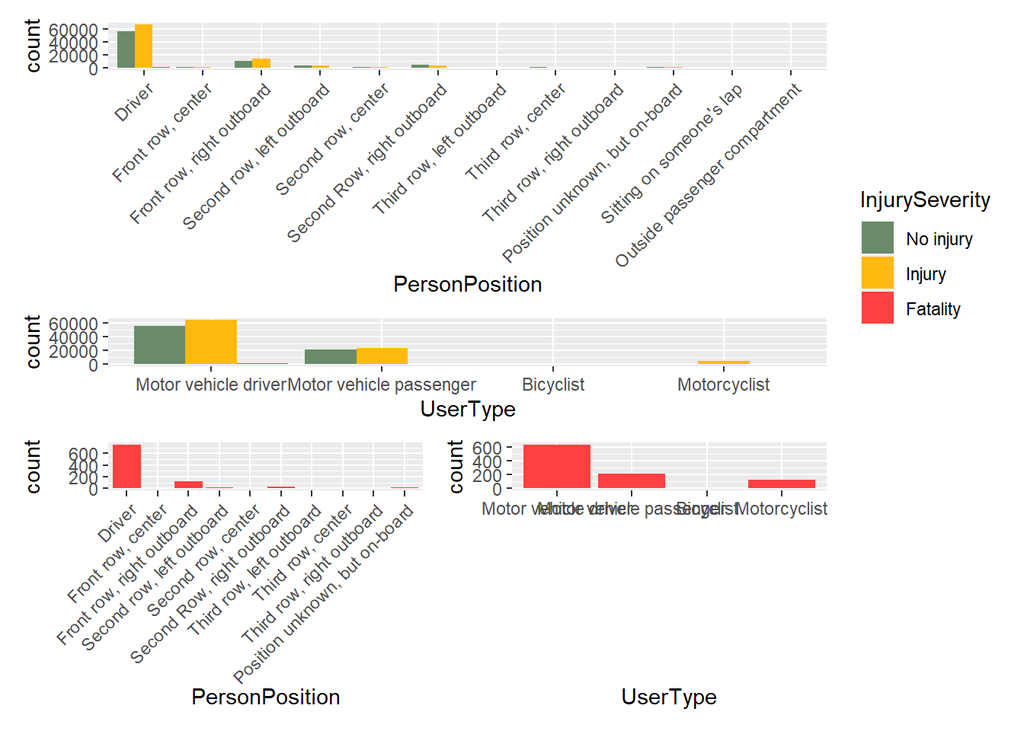

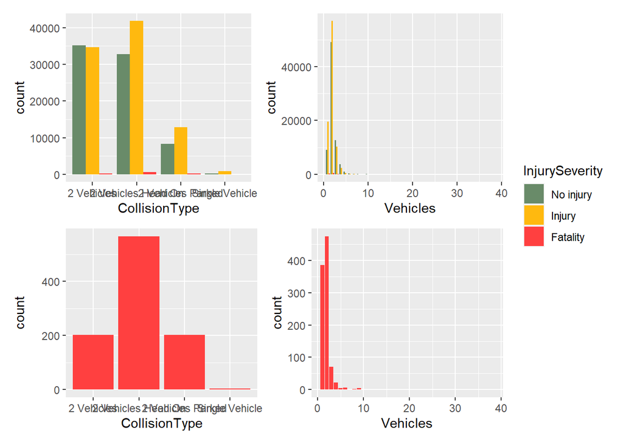

The data is distributed in such a way that the majority of the results of the target variable InjurySeverity are either No injury or Injury. No injury makes up (76530)/167803 or 45.6% of cases, Injury makes up (90299)/167807 or 53.8% leaving only 974/167807 or 0.5% resulting in fatalities.  
Fortunately, given the size of the data, we can acquire 3 suitably equal sized samples of the data for training and testing purposes.

```r
fatalSet <- data %>%
  filter(InjurySeverity == "Fatality") %>%
  sample_n(900)

injurySet <- data %>%
  filter(InjurySeverity == "Injury") %>%
  sample_n(900)

noInjurySet <- data %>%
  filter(InjurySeverity == "No injury") %>%
  sample_n((900))

data <- bind_rows(fatalSet,injurySet,noInjurySet, .id = NULL)
```